# Econometrics 2017(fall)- Stata- IV, Panel, RDD & DID

**Nanjing University**  
**Xiaoguang Ling**  
**2018.01.03**

Note:

(1)The data and code for IV and Panel Data used below(section 1 & 2) is mostly from http://www.stata-press.com/data/mus.html. Copyright C 2008 by A. Colin Cameron and Pravin K. Trivedi. See also: [Microeconometrics using Stata](https://www.stata.com/bookstore/microeconometrics-stata/) by A. Colin Cameron and Pravin K. Trivedi (2008)

(2)The data and code for RDD (section 3) is mostly provided by [Calonico S et al.](http://sites.googole.com/repackages/rdrobust/stata)

Here are some useful references for RDD：

> [1]Calonico S, Cattaneo M D, Titiunik R. Robust data-driven inference in the regression-discontinuity design[J]. Stata Journal, 2014, 14(4):909-946.

> [2]Calonico S, Cattaneo M D, Farrell M H, et al. rdrobust: Software for regression discontinuity designs[J]. Unpublished manuscript available at: http://faculty. chicagobooth. edu/max. farrell/research/Calonico-Cattaneo- Farrell-Titiunik_2016_Stata. pdf, 2016.

(3)The Example 1&2 used for Synthetic Control Method(section 4) are from the default expamples of the Stata Package: synth, developed by Jens Hainmueller, Alberto Abadie & Alexis Diamond. Section 4.2 is provided by [Michael Jankowski](https://www.statalist.org/forums/forum/general-stata-discussion/general/1303878-placebo-tests-for-synthetic-control-method)

More about the method and empirical background, please refer to:Abadie, A., Diamond, A., and J. Hainmueller. 2010. Synthetic Control Methods for Comparative Case Studies:Estimating the Effect of California's Tobacco Control Program. Journal of the American Statistical Association 105(490): 493-505.

# 1.IV

## 1.1. INSTRUMENTAL VARIABLES EXAMPLE

```stata
. clear all

. global root C:\Users\Xiaoguang\OneDrive\2017Econometrics\Stata

. cd $root\rawdata\IV
C:\Users\Xiaoguang\OneDrive\2017Econometrics\Stata\rawdata\IV

. use mus06data,clear
```

### Case study: Medical expenditures with one endogenous regressor

**Dependent variable**:

ldrugexp, the log of total out-of-pocket expenditures on prescribed medications.

**The regressors**:

whether the individual holds either employer or union-sponsored health insurance (hi_empunion)

number of chronic conditions (totchr)

age in years (age), whether female (female) whether black or Hispanic (blhisp ) and the natural logarithm of annual household income in thousands of dollars (linc)

**Endogenous variable**: hi_empunion

**Available instruments**:

*ssiratio*: the ratio of an individual's social security income to the individual's income from all sources, with high values indicating a significant income constraint.

*firmsz*: the size of t he firm's employed labor force

**Relevance**: (1)*ssiratio* is expected to be negatively correlated with having supplementary insurance (hi_empunion).

(2)*firmsz* intended to capture whether the individual has access to supplementary insurance through the employer.

**Exogeneity**: (1)*ssiratio* is orthogonal to error term (u_i). Actually, we can assume that the direct role of income is adequately captured by the regressor linc. Therefore nothing in u_i is related to *ssiratio*.

(2)However, *firmsz* may be related to the intention of individuals to obtain supplementary insurance, which is the omitted variable hiding in u_i. The OIR test will help to show this.

## 1.2. IV estimation with single endog regressor

### Define global x2list & summarize data

```stata
. global x2list totchr age female blhisp linc

. summarize ldrugexp hi_empunion $x2list

    Variable │        Obs        Mean    Std. Dev.       Min        Max
─────────────┼─────────────────────────────────────────────────────────
    ldrugexp │     10,391    6.479668    1.363395          0   10.18017
 hi_empunion │     10,391    .3796555    .4853245          0          1
      totchr │     10,391    1.860745    1.290131          0          9
         age │     10,391    75.04639     6.69368         65         91
      female │     10,391    .5797325    .4936256          0          1
─────────────┼─────────────────────────────────────────────────────────
      blhisp │     10,391    .1703397    .3759491          0          1
        linc │     10,089    2.743275    .9131433  -6.907755   5.744476
```

**OLS**

```stata
. qui reg ldrugexp hi_empunion $x2list, r

. estimate store OLS
```

### Exact identification

```stata
. ivregress 2sls ldrugexp (hi_empunion = ssiratio) $x2list, vce(robust) first

First-stage regressions
───────────────────────

                                                Number of obs     =     10,089
                                                F(   6,  10082)   =     119.18
                                                Prob > F          =     0.0000
                                                R-squared         =     0.0761
                                                Adj R-squared     =     0.0755
                                                Root MSE          =     0.4672

─────────────┬────────────────────────────────────────────────────────────────
             │               Robust
 hi_empunion │      Coef.   Std. Err.      t    P>|t|     [95% Conf. Interval]
─────────────┼────────────────────────────────────────────────────────────────
      totchr │   .0127865   .0036655     3.49   0.000     .0056015    .0199716
         age │  -.0086323   .0007087   -12.18   0.000    -.0100216   -.0072431
      female │    -.07345   .0096392    -7.62   0.000    -.0923448   -.0545552
      blhisp │    -.06268   .0122742    -5.11   0.000      -.08674   -.0386201
        linc │   .0483937   .0066075     7.32   0.000     .0354417    .0613456
    ssiratio │  -.1916432   .0236326    -8.11   0.000    -.2379678   -.1453186
       _cons │   1.028981   .0581387    17.70   0.000     .9150172    1.142944
─────────────┴────────────────────────────────────────────────────────────────


Instrumental variables (2SLS) regression          Number of obs   =     10,089
                                                  Wald chi2(6)    =    2000.86
                                                  Prob > chi2     =     0.0000
                                                  R-squared       =     0.0640
                                                  Root MSE        =     1.3177

─────────────┬────────────────────────────────────────────────────────────────
             │               Robust
    ldrugexp │      Coef.   Std. Err.      z    P>|z|     [95% Conf. Interval]
─────────────┼────────────────────────────────────────────────────────────────
 hi_empunion │  -.8975913   .2211268    -4.06   0.000    -1.330992   -.4641908
      totchr │   .4502655   .0101969    44.16   0.000       .43028     .470251
         age │  -.0132176   .0029977    -4.41   0.000    -.0190931   -.0073421
      female │   -.020406   .0326114    -0.63   0.531    -.0843232    .0435113
      blhisp │  -.2174244   .0394944    -5.51   0.000     -.294832   -.1400167
        linc │   .0870018   .0226356     3.84   0.000     .0426368    .1313668
       _cons │    6.78717   .2688453    25.25   0.000     6.260243    7.314097
─────────────┴────────────────────────────────────────────────────────────────
Instrumented:  hi_empunion
Instruments:   totchr age female blhisp linc ssiratio
```

### Relevance test. More about [partial $R^2$](https://onlinecourses.science.psu.edu/stat501/node/312).

```stata
. estat firststage

  First-stage regression summary statistics
  ─────────────┬────────────────────────────────────────────────────────────
               │            Adjusted      Partial       Robust
      Variable │   R-sq.       R-sq.        R-sq.    F(1,10082)   Prob > F
  ─────────────┼────────────────────────────────────────────────────────────
   hi_empunion │  0.0761      0.0755       0.0179       65.7602    0.0000
  ─────────────┴────────────────────────────────────────────────────────────


. estimate store IV1
```

### Over identification

```stata
. qui ivregress 2sls ldrugexp (hi_empunion = ssiratio firmsz) $x2list, vce(robust) first

. estat firststage

  First-stage regression summary statistics
  ─────────────┬────────────────────────────────────────────────────────────
               │            Adjusted      Partial       Robust
      Variable │   R-sq.       R-sq.        R-sq.    F(2,10081)   Prob > F
  ─────────────┼────────────────────────────────────────────────────────────
   hi_empunion │  0.0767      0.0761       0.0186       39.4414    0.0000
  ─────────────┴────────────────────────────────────────────────────────────


.    estimate store IV2
```

### OIR: A statistically significant test statistic always indicates that at least one instrument may not be valid.

```stata
. estat overid

  Test of overidentifying restrictions:

  Score chi2(1)          =  3.68948  (p = 0.0548)

. outreg2 [OLS IV*] using "$root\tables\IV.xls",  bdec(3) sdec(3) replace
C:\Users\Xiaoguang\OneDrive\2017Econometrics\Stata\tables\IV.xls
dir : seeout

. estimates clear
```

**Table 1. IV**

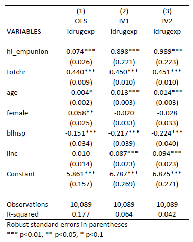

# 2.PANEL DATA

## 2.1.PANEL-DATA MANAGEMENT

```stata
. cd $root\rawdata\panel
C:\Users\Xiaoguang\OneDrive\2017Econometrics\Stata\rawdata\panel
```

### Wide form data (observation is a state)

```stata
. use mus08cigarwide.dta, clear

. list, clean

       state   lnp63   lnc63   lnp64   lnc64   lnp65   lnc65
  1.       1     4.5     4.5     4.6     4.6     4.5     4.6
  2.       2     4.4     4.8     4.3     4.8     4.3     4.8
  3.       3     4.5     4.6     4.5     4.6     4.5     4.6
  4.       4     4.4     5.0     4.4     4.9     4.4     4.9
  5.       5     4.5     5.1     4.5     5.0     4.5     5.0
  6.       6     4.5     5.1     4.5     5.1     4.5     5.1
  7.       7     4.3     5.5     4.3     5.5     4.3     5.5
  8.       8     4.5     4.9     4.6     4.8     4.5     4.9
  9.       9     4.5     4.7     4.5     4.7     4.6     4.6
 10.      10     4.5     4.6     4.6     4.5     4.5     4.6
```

### Wide form to long form (state-year pair)

```stata
. reshape long lnp lnc, i(state) j(year)
(note: j = 63 64 65)

Data                               wide   ->   long
─────────────────────────────────────────────────────────────────────────────
Number of obs.                       10   ->      30
Number of variables                   7   ->       4
j variable (3 values)                     ->   year
xij variables:
                      lnp63 lnp64 lnp65   ->   lnp
                      lnc63 lnc64 lnc65   ->   lnc
─────────────────────────────────────────────────────────────────────────────
```

```stata
. list in 1/6, sepby(state)

     ┌──────────────────────────┐
     │ state   year   lnp   lnc │
     ├──────────────────────────┤
  1. │     1     63   4.5   4.5 │
  2. │     1     64   4.6   4.6 │
  3. │     1     65   4.5   4.6 │
     ├──────────────────────────┤
  4. │     2     63   4.4   4.8 │
  5. │     2     64   4.3   4.8 │
  6. │     2     65   4.3   4.8 │
     └──────────────────────────┘
```

### Reconvert from long form to wide form (observation is a state)

```stata
. reshape wide lnp lnc, i(state) j(year)
(note: j = 63 64 65)

Data                               long   ->   wide
─────────────────────────────────────────────────────────────────────────────
Number of obs.                       30   ->      10
Number of variables                   4   ->       7
j variable (3 values)              year   ->   (dropped)
xij variables:
                                    lnp   ->   lnp63 lnp64 lnp65
                                    lnc   ->   lnc63 lnc64 lnc65
─────────────────────────────────────────────────────────────────────────────

. list, clean

       state   lnp63   lnc63   lnp64   lnc64   lnp65   lnc65
  1.       1     4.5     4.5     4.6     4.6     4.5     4.6
  2.       2     4.4     4.8     4.3     4.8     4.3     4.8
  3.       3     4.5     4.6     4.5     4.6     4.5     4.6
  4.       4     4.4     5.0     4.4     4.9     4.4     4.9
  5.       5     4.5     5.1     4.5     5.0     4.5     5.0
  6.       6     4.5     5.1     4.5     5.1     4.5     5.1
  7.       7     4.3     5.5     4.3     5.5     4.3     5.5
  8.       8     4.5     4.9     4.6     4.8     4.5     4.9
  9.       9     4.5     4.7     4.5     4.7     4.6     4.6
 10.      10     4.5     4.6     4.6     4.5     4.5     4.6
```

### Create alternative wide-form data (observation is a year)

```stata
. quietly reshape long lnp lnc, i(state) j(year)

. reshape wide lnp lnc, i(year) j(state)
(note: j = 1 2 3 4 5 6 7 8 9 10)

Data                               long   ->   wide
─────────────────────────────────────────────────────────────────────────────
Number of obs.                       30   ->       3
Number of variables                   4   ->      21
j variable (10 values)            state   ->   (dropped)
xij variables:
                                    lnp   ->   lnp1 lnp2 ... lnp10
                                    lnc   ->   lnc1 lnc2 ... lnc10
─────────────────────────────────────────────────────────────────────────────

. list year lnp1 lnp2 lnc1 lnc2, clean

       year   lnp1   lnp2   lnc1   lnc2
  1.     63    4.5    4.4    4.5    4.8
  2.     64    4.6    4.3    4.6    4.8
  3.     65    4.5    4.3    4.6    4.8
```

### Convert from wide form (observation is year) to long form (year-state)

```stata
. reshape long lnp lnc, i(year) j(state)
(note: j = 1 2 3 4 5 6 7 8 9 10)

Data                               wide   ->   long
─────────────────────────────────────────────────────────────────────────────
Number of obs.                        3   ->      30
Number of variables                  21   ->       4
j variable (10 values)                    ->   state
xij variables:
                    lnp1 lnp2 ... lnp10   ->   lnp
                    lnc1 lnc2 ... lnc10   ->   lnc
─────────────────────────────────────────────────────────────────────────────

. list in 1/6, clean

       year   state   lnp   lnc
  1.     63       1   4.5   4.5
  2.     63       2   4.4   4.8
  3.     63       3   4.5   4.6
  4.     63       4   4.4   5.0
  5.     63       5   4.5   5.1
  6.     63       6   4.5   5.1
```

## 2.2.PANEL DATA SUMMARY AND ESTIMATION

```stata
. use mus08psidextract,clear
(PSID wage data 1976-82 from Baltagi and Khanti-Akom (1990))

. list id t exp wks occ ind south in 1/15, clean

       id   t   exp   wks   occ   ind   south
  1.    1   1     3    32     0     0       1
  2.    1   2     4    43     0     0       1
  3.    1   3     5    40     0     0       1
  4.    1   4     6    39     0     0       1
  5.    1   5     7    42     0     1       1
  6.    1   6     8    35     0     1       1
  7.    1   7     9    32     0     1       1
  8.    2   1    30    34     1     0       0
  9.    2   2    31    27     1     0       0
 10.    2   3    32    33     1     1       0
 11.    2   4    33    30     1     1       0
 12.    2   5    34    30     1     1       0
 13.    2   6    35    37     1     1       0
 14.    2   7    36    30     1     1       0
 15.    3   1     6    50     1     1       0
```

### Declare individual identifier and time identifier

```stata
. xtset id t
       panel variable:  id (strongly balanced)
        time variable:  t, 1 to 7
                delta:  1 unit
```

```stata
. drop if id==1 &t==1
(1 observation deleted)

. drop if id==4 &t==4
(1 observation deleted)

. xtset id t
       panel variable:  id (unbalanced)
        time variable:  t, 1 to 7, but with a gap
                delta:  1 unit
```

### Panel description of dataset

```stata
. xtdescribe

      id:  1, 2, ..., 595                                    n =        595
       t:  1, 2, ..., 7                                      T =          7
           Delta(t) = 1 unit
           Span(t)  = 7 periods
           (id*t uniquely identifies each observation)

Distribution of T_i:   min      5%     25%       50%       75%     95%     max
                         6       7       7         7         7       7       7

     Freq.  Percent    Cum. │  Pattern
 ───────────────────────────┼─────────
      593     99.66   99.66 │  1111111
        1      0.17   99.83 │  .111111
        1      0.17  100.00 │  111.111
 ───────────────────────────┼─────────
      595    100.00         │  XXXXXXX
```

#### Within of FE estimator with cluster-robust standard errors

$$(y_{it}-\bar{y}_i+\bar{\bar{y}})=\alpha+(x_{it}-\bar{x}_i+\bar{\bar{x}})'{\beta}+({\epsilon}_{it}-\bar{{\epsilon}}_i+\bar{\bar{{\epsilon}}})$$

$$(y_{it}-\bar{y}_i+\bar{\bar{y}})=\alpha+(x_{it}-\bar{x}_i+\bar{\bar{x}})'{\beta}+({\epsilon}_{it}-\bar{{\epsilon}}_i+\bar{\bar{{\epsilon}}})$$
The $R^2$ from the mean-deviated regression:
$$Within R^2: {\rho}^{2}\{({y}_{it}-{\bar{y}}_{i}),({x'}_{it}{\hat{\beta}}-{\bar{x}}'_{it}{\hat{\beta}})\}$$
The combined error in the individual-effects model that we label $\alpha_i +\epsilon_i$ is referred to as $u_i + e_i$ in the Stata documentation and output.Thus Stata output **sigma_u** gives the standard deviation of the individual effect $\alpha$, and **sigma_e** gives the standard deviation of $\epsilon$·

```stata
. use mus08psidextract,clear
(PSID wage data 1976-82 from Baltagi and Khanti-Akom (1990))

. xtreg lwage exp exp2, fe vce(cluster id)

Fixed-effects (within) regression               Number of obs     =      4,165
Group variable: id                              Number of groups  =        595

R-sq:                                           Obs per group:
     within  = 0.6564                                         min =          7
     between = 0.0276                                         avg =        7.0
     overall = 0.0475                                         max =          7

                                                F(2,594)          =    1588.25
corr(u_i, Xb)  = -0.9107                        Prob > F          =     0.0000

                                   (Std. Err. adjusted for 595 clusters in id)
─────────────┬────────────────────────────────────────────────────────────────
             │               Robust
       lwage │      Coef.   Std. Err.      t    P>|t|     [95% Conf. Interval]
─────────────┼────────────────────────────────────────────────────────────────
         exp │   .1139829   .0040294    28.29   0.000     .1060692    .1218966
        exp2 │  -.0004294   .0000821    -5.23   0.000    -.0005907   -.0002681
       _cons │   4.634238   .0452661   102.38   0.000     4.545337    4.723139
─────────────┼────────────────────────────────────────────────────────────────
     sigma_u │  1.0361517
     sigma_e │  .15222327
         rho │  .97887281   (fraction of variance due to u_i)
─────────────┴────────────────────────────────────────────────────────────────

. estimate store xt1
```

```stata
. xtreg lwage exp exp2 tdum2 - tdum7, fe vce(cluster id)
note: tdum7 omitted because of collinearity

Fixed-effects (within) regression               Number of obs     =      4,165
Group variable: id                              Number of groups  =        595

R-sq:                                           Obs per group:
     within  = 0.6597                                         min =          7
     between = 0.0275                                         avg =        7.0
     overall = 0.0479                                         max =          7

                                                F(7,594)          =     471.29
corr(u_i, Xb)  = -0.9089                        Prob > F          =     0.0000

                                   (Std. Err. adjusted for 595 clusters in id)
─────────────┬────────────────────────────────────────────────────────────────
             │               Robust
       lwage │      Coef.   Std. Err.      t    P>|t|     [95% Conf. Interval]
─────────────┼────────────────────────────────────────────────────────────────
         exp │   .1121608    .004119    27.23   0.000     .1040713    .1202503
        exp2 │  -.0004088   .0000834    -4.90   0.000    -.0005726    -.000245
       tdum2 │  -.0079337   .0049652    -1.60   0.111    -.0176851    .0018178
       tdum3 │   .0264163   .0082418     3.21   0.001     .0102296     .042603
       tdum4 │   .0294408   .0077336     3.81   0.000     .0142522    .0446294
       tdum5 │   .0242958   .0065353     3.72   0.000     .0114607    .0371309
       tdum6 │   .0071848   .0064406     1.12   0.265    -.0054644     .019834
       tdum7 │          0  (omitted)
       _cons │   4.648474   .0458225   101.45   0.000      4.55848    4.738468
─────────────┼────────────────────────────────────────────────────────────────
     sigma_u │  1.0270872
     sigma_e │  .15159656
         rho │  .97867916   (fraction of variance due to u_i)
─────────────┴────────────────────────────────────────────────────────────────

. estimate store xt2
```

```stata
. outreg2 [xt*] using "$root\tables\xtreg.xls",  bdec(3) sdec(3) replace
C:\Users\Xiaoguang\OneDrive\2017Econometrics\Stata\tables\xtreg.xls
dir : seeout

. estimates clear
```

**Table 2. Panel Data**

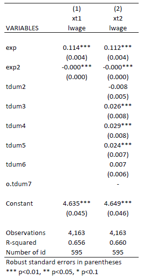

# 3.RDD

## 3.1. Case Study

```stata
. sysuse rdrobust_senate.dta, clear

. cd C:\Users\Xiaoguang\OneDrive\2017Econometrics\Stata\tables
C:\Users\Xiaoguang\OneDrive\2017Econometrics\Stata\tables

. sum vote margin class termshouse termssenate population, sep(2)

    Variable │        Obs        Mean    Std. Dev.       Min        Max
─────────────┼─────────────────────────────────────────────────────────
        vote │      1,297    52.66627    18.12219          0        100
      margin │      1,390    7.171159    34.32488       -100        100
─────────────┼─────────────────────────────────────────────────────────
       class │      1,390    2.023022    .8231983          1          3
  termshouse │      1,108    1.436823    2.357133          0         16
─────────────┼─────────────────────────────────────────────────────────
 termssenate │      1,108    4.555957    3.720294          1         20
  population │      1,390     3827919     4436950      78000   3.73e+07
```

termshouse termssenate:experience

vote: vote share in the next round of election

margin: the vote share of the Democratic party minus the vote share of its strongest opponent

class: electoral class

## 3.2. rdrobust

```stata
. rdplot vote margin, ///
>        graph_options(title(RD Plot - Senate elections data) ///
>                            ytitle(Vote share in election at time t+1) ///
>                            xtitle(Vote share in election at time t))

RD Plot with evenly spaced mimicking variance number of bins using spacings estimators.

         Cutoff c = 0 │ Left of c  Right of c        Number of obs  =       1297
──────────────────────┼──────────────────────        Kernel         =    Uniform
        Number of obs │       595         702
   Eff. Number of obs │       595         702
  Order poly. fit (p) │         4           4
     BW poly. fit (h) │   100.000     100.000
 Number of bins scale │     1.000       1.000

Outcome: vote. Running variable: margin.
──────────────────────┬──────────────────────
                      │ Left of c  Right of c
──────────────────────┼──────────────────────
        Bins selected │        15          35
   Average bin length │     6.667       2.857
    Median bin length │     6.667       2.857
──────────────────────┼──────────────────────
    IMSE-optimal bins │         8           9
  Mimicking Var. bins │        15          35
──────────────────────┼──────────────────────
Rel. to IMSE-optimal: │
        Implied scale │     1.875       3.889
    WIMSE var. weight │     0.132       0.017
    WIMSE bias weight │     0.868       0.983
──────────────────────┴──────────────────────
```

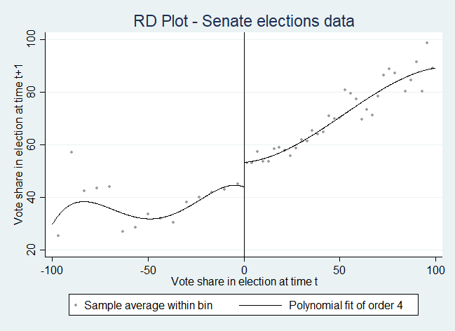

```stata
. graph export 3.png, replace
(file 3.png written in PNG format)
```

**Picture 1. RD Plot**

```stata
. rdrobust vote margin

Sharp RD estimates using local polynomial regression.

      Cutoff c = 0 │ Left of c  Right of c            Number of obs =       1297
───────────────────┼──────────────────────            BW type       =      mserd
     Number of obs │       595         702            Kernel        = Triangular
Eff. Number of obs │       359         322            VCE method    =         NN
    Order est. (p) │         1           1
    Order bias (q) │         2           2
       BW est. (h) │    17.708      17.708
       BW bias (b) │    27.984      27.984
         rho (h/b) │     0.633       0.633

Outcome: vote. Running variable: margin.
───────────────────┬────────────────────────────────────────────────────────────
            Method │   Coef.    Std. Err.    z     P>|z|    [95% Conf. Interval]
───────────────────┼────────────────────────────────────────────────────────────
      Conventional │   7.416     1.4604   5.0782   0.000    4.55378      10.2783
            Robust │     -          -     4.3095   0.000    4.09441      10.9255
───────────────────┴────────────────────────────────────────────────────────────
```

Note:*the default output is "Conventional Poly. Estimator"*

```stata
. rdrobust vote margin, covs(class termshouse termssenate)

Covariate-adjusted sharp RD estimates using local polynomial regression.

      Cutoff c = 0 │ Left of c  Right of c            Number of obs =       1108
───────────────────┼──────────────────────            BW type       =      mserd
     Number of obs │       491         617            Kernel        = Triangular
Eff. Number of obs │       313         283            VCE method    =         NN
    Order est. (p) │         1           1
    Order bias (q) │         2           2
       BW est. (h) │    17.987      17.987
       BW bias (b) │    28.943      28.943
         rho (h/b) │     0.621       0.621

Outcome: vote. Running variable: margin.
───────────────────┬────────────────────────────────────────────────────────────
            Method │   Coef.    Std. Err.    z     P>|z|    [95% Conf. Interval]
───────────────────┼────────────────────────────────────────────────────────────
      Conventional │  6.8514     1.4081   4.8656   0.000    4.09148      9.61125
            Robust │     -          -     4.1999   0.000    3.72856      10.2537
───────────────────┴────────────────────────────────────────────────────────────
Covariate-adjusted estimates. Additional covariates included: 3

. outreg2 using rd.xls, replace addstat( Bias-corrected RD_Estimate, ///
>  e(tau_bc) ,Robust Std. Error, e(se_tau_rb),Order Loc. Poly. ///
> (p),e(p),Order Bias (q),e(q))  obs notes adec(3)
rd.xls
dir : seeout
```

**Table 3. RDD**

[figure not shown]

# 4.DID(Synthetic Control)

## 4.1.Construct synthetic control group:

Load Example Data: This panel dataset contains information for 39 US States for the years 1970-2000 (see Abadie, Diamond, and Hainmueller (2010) for details).

```stata
. sysuse smoking
(Tobacco Sales in 39 US States)

. cd C:\Users\Xiaoguang\OneDrive\2017Econometrics\Stata\workingdata\synth
C:\Users\Xiaoguang\OneDrive\2017Econometrics\Stata\workingdata\synth
```

Declare the dataset as panel:

```stata
. xtset state year
       panel variable:  state (strongly balanced)
        time variable:  year, 1970 to 2000
                delta:  1 unit

. sum

    Variable │        Obs        Mean    Std. Dev.       Min        Max
─────────────┼─────────────────────────────────────────────────────────
       state │      1,209          20    11.25929          1         39
        year │      1,209        1985    8.947973       1970       2000
     cigsale │      1,209    118.8932     32.7674       40.7      296.2
    lnincome │      1,014    9.861634    .1706769   9.397449   10.48662
        beer │        546     23.4304     4.22319        2.5       40.4
─────────────┼─────────────────────────────────────────────────────────
   age15to24 │        819     .175472    .0151589   .1294482   .2036753
    retprice │      1,209    108.3419    64.38199       27.3      351.2

. list in 1/10

     ┌──────────────────────────────────────────────────────────────────┐
     │   state   year   cigsale   lnincome   beer   age15~24   retprice │
     ├──────────────────────────────────────────────────────────────────┤
  1. │ Alabama   1970      89.8          .      .   .1788618       39.6 │
  2. │ Alabama   1971      95.4          .      .   .1799278       42.7 │
  3. │ Alabama   1972     101.1   9.498476      .   .1809939       42.3 │
  4. │ Alabama   1973     102.9   9.550107      .   .1820599       42.1 │
  5. │ Alabama   1974     108.2   9.537163      .    .183126       43.1 │
     ├──────────────────────────────────────────────────────────────────┤
  6. │ Alabama   1975     111.7   9.540031      .   .1841921       46.6 │
  7. │ Alabama   1976     116.2   9.591908      .   .1852581       50.4 │
  8. │ Alabama   1977     117.1   9.617496      .   .1863242       50.1 │
  9. │ Alabama   1978       123   9.654072      .   .1873902       55.1 │
 10. │ Alabama   1979     121.4    9.64918      .   .1884563       56.8 │
     └──────────────────────────────────────────────────────────────────┘
```

### Example 1

beer(1984(1)1988):The beer variable has the time period (1984(1)1988) specified, meaning that it is averaged for the periods 1984,1985,...,1988.

cigsale(1988) cigsale(1980) cigsale(1975): The variable cigsale will be used three times as a predictor using the values from periods 1988, 1980, and 1975 respectively.

trunit(3):the unit affected by the intervention is unit no 3 (California) in the year 1989.

counit():The donor pool (since no counit() is specified) defaults to the control units 1,2,4,5,...,39 ( ie. the other 38 states in the dataset).

xperiod():Since no xperiod() is provided, the predictor variables for which no variable specific time period is specified (retprice, lnincome, and age15to24) are averaged over the entire pre-intervention period up to the year of the intervention (1970,1981,...,1988).

mspeperiod(): The MSPE is minimized over the entire pretreatment period, because mspeperiod() is not provided.

By default, results are displayed for the period from 1970,1971,...,2000 period (the earliest and latest year in the dataset).

A results figure is also requested using the fig option.

```stata
. synth cigsale beer(1984(1)1988) lnincome retprice age15to24 cigsale(1988) cigsale(1980) c
> igsale(1975), ///
> trunit(3) trperiod(1989) fig
───────────────────────────────────────────────────────────────────────────────────────────
Synthetic Control Method for Comparative Case Studies
───────────────────────────────────────────────────────────────────────────────────────────

First Step: Data Setup
───────────────────────────────────────────────────────────────────────────────────────────
control units: for 38 of out 38 units missing obs for predictor lnincome in period 1970 -ig
> nored for averaging
control units: for 38 of out 38 units missing obs for predictor lnincome in period 1971 -ig
> nored for averaging
treated unit: for 1 of out 1 units missing obs for predictor lnincome in period 1970 -ignor
> ed for averaging
treated unit: for 1 of out 1 units missing obs for predictor lnincome in period 1971 -ignor
> ed for averaging
───────────────────────────────────────────────────────────────────────────────────────────
Data Setup successful
───────────────────────────────────────────────────────────────────────────────────────────
                Treated Unit: California
               Control Units: Alabama, Arkansas, Colorado, Connecticut, Delaware, Georgia,
                              Idaho, Illinois, Indiana, Iowa, Kansas, Kentucky, Louisiana,
                              Maine, Minnesota, Mississippi, Missouri, Montana, Nebraska,
                              Nevada, New Hampshire, New Mexico, North Carolina, North
                              Dakota, Ohio, Oklahoma, Pennsylvania, Rhode Island, South
                              Carolina, South Dakota, Tennessee, Texas, Utah, Vermont,
                              Virginia, West Virginia, Wisconsin, Wyoming
───────────────────────────────────────────────────────────────────────────────────────────
          Dependent Variable: cigsale
  MSPE minimized for periods: 1970 1971 1972 1973 1974 1975 1976 1977 1978 1979 1980 1981
                              1982 1983 1984 1985 1986 1987 1988
Results obtained for periods: 1970 1971 1972 1973 1974 1975 1976 1977 1978 1979 1980 1981
                              1982 1983 1984 1985 1986 1987 1988 1989 1990 1991 1992 1993
                              1994 1995 1996 1997 1998 1999 2000
───────────────────────────────────────────────────────────────────────────────────────────
                  Predictors: beer(1984(1)1988) lnincome retprice age15to24 cigsale(1988)
                              cigsale(1980) cigsale(1975)
───────────────────────────────────────────────────────────────────────────────────────────
Unless period is specified
predictors are averaged over: 1970 1971 1972 1973 1974 1975 1976 1977 1978 1979 1980 1981
                              1982 1983 1984 1985 1986 1987 1988
───────────────────────────────────────────────────────────────────────────────────────────

Second Step: Run Optimization
───────────────────────────────────────────────────────────────────────────────────────────
───────────────────────────────────────────────────────────────────────────────────────────
Optimization done
───────────────────────────────────────────────────────────────────────────────────────────

Third Step: Obtain Results
───────────────────────────────────────────────────────────────────────────────────────────
Loss: Root Mean Squared Prediction Error

─────────────────────
   RMSPE │  1.943233
─────────────────────
───────────────────────────────────────────────────────────────────────────────────────────
Unit Weights:

───────────────┬────────────
         Co_No │ Unit_Weight
───────────────┼────────────
       Alabama │           0
      Arkansas │           0
      Colorado │        .285
   Connecticut │        .101
      Delaware │           0
       Georgia │           0
         Idaho │           0
      Illinois │           0
       Indiana │           0
          Iowa │           0
        Kansas │           0
      Kentucky │           0
     Louisiana │           0
         Maine │           0
     Minnesota │           0
   Mississippi │           0
      Missouri │           0
       Montana │           0
      Nebraska │           0
        Nevada │        .245
 New Hampshire │           0
    New Mexico │           0
North Carolina │           0
  North Dakota │           0
          Ohio │           0
      Oklahoma │           0
  Pennsylvania │           0
  Rhode Island │           0
South Carolina │           0
  South Dakota │           0
     Tennessee │           0
         Texas │           0
          Utah │        .369
       Vermont │           0
      Virginia │           0
 West Virginia │           0
     Wisconsin │           0
       Wyoming │           0
───────────────┴────────────
───────────────────────────────────────────────────────────────────────────────────────────
Predictor Balance:

──────────────────────────────────────────────────────
                               │   Treated  Synthetic
───────────────────────────────+──────────────────────
             beer(1984(1)1988) │     24.28   23.22596
                      lnincome │  10.03176   9.867266
                      retprice │  66.63684   65.40743
                     age15to24 │  .1786624   .1825559
                 cigsale(1988) │      90.1    92.6063
                 cigsale(1980) │     120.2   120.3907
                 cigsale(1975) │     127.1   126.7094
──────────────────────────────────────────────────────
───────────────────────────────────────────────────────────────────────────────────────────
```

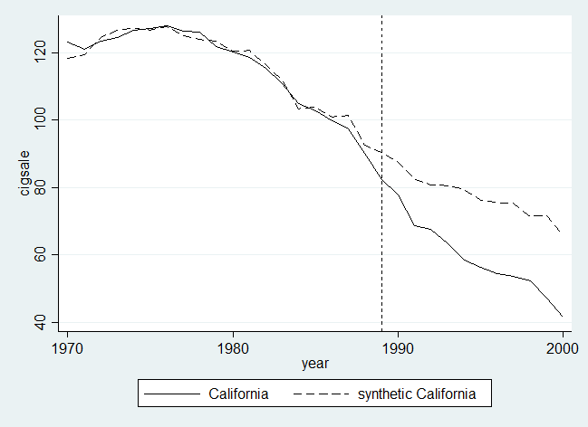

```stata
.    graph export 5.png, replace
(file 5.png written in PNG format)
```

**Picture 2. Synthetic Control-1**

### Example 2 - Construct synthetic control group:

This example is similar to example 1, but now beer is averaged over the entire pretreatment period while lnincome is only averaged over the periods 1980 and 1985.

Since no data is available for beer prior to 1984, synth will inform the user that there is missing data for this variable and that the missing values are ignored in the averaging.

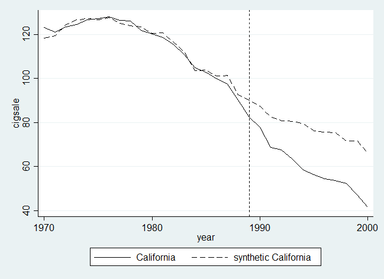

```stata
. synth cigsale beer lnincome(1980&1985) retprice cigsale(1988) cigsale(1980) cigsale(1975)
> , ///
> trunit(3) trperiod(1989) fig
───────────────────────────────────────────────────────────────────────────────────────────
Synthetic Control Method for Comparative Case Studies
───────────────────────────────────────────────────────────────────────────────────────────

First Step: Data Setup
───────────────────────────────────────────────────────────────────────────────────────────
control units: for 38 of out 38 units missing obs for predictor beer in period 1970 -ignore
> d for averaging
control units: for 38 of out 38 units missing obs for predictor beer in period 1971 -ignore
> d for averaging
control units: for 38 of out 38 units missing obs for predictor beer in period 1972 -ignore
> d for averaging
control units: for 38 of out 38 units missing obs for predictor beer in period 1973 -ignore
> d for averaging
control units: for 38 of out 38 units missing obs for predictor beer in period 1974 -ignore
> d for averaging
control units: for 38 of out 38 units missing obs for predictor beer in period 1975 -ignore
> d for averaging
control units: for 38 of out 38 units missing obs for predictor beer in period 1976 -ignore
> d for averaging
control units: for 38 of out 38 units missing obs for predictor beer in period 1977 -ignore
> d for averaging
control units: for 38 of out 38 units missing obs for predictor beer in period 1978 -ignore
> d for averaging
control units: for 38 of out 38 units missing obs for predictor beer in period 1979 -ignore
> d for averaging
control units: for 38 of out 38 units missing obs for predictor beer in period 1980 -ignore
> d for averaging
control units: for 38 of out 38 units missing obs for predictor beer in period 1981 -ignore
> d for averaging
control units: for 38 of out 38 units missing obs for predictor beer in period 1982 -ignore
> d for averaging
control units: for 38 of out 38 units missing obs for predictor beer in period 1983 -ignore
> d for averaging
treated unit: for 1 of out 1 units missing obs for predictor beer in period 1970 -ignored f
> or averaging
treated unit: for 1 of out 1 units missing obs for predictor beer in period 1971 -ignored f
> or averaging
treated unit: for 1 of out 1 units missing obs for predictor beer in period 1972 -ignored f
> or averaging
treated unit: for 1 of out 1 units missing obs for predictor beer in period 1973 -ignored f
> or averaging
treated unit: for 1 of out 1 units missing obs for predictor beer in period 1974 -ignored f
> or averaging
treated unit: for 1 of out 1 units missing obs for predictor beer in period 1975 -ignored f
> or averaging
treated unit: for 1 of out 1 units missing obs for predictor beer in period 1976 -ignored f
> or averaging
treated unit: for 1 of out 1 units missing obs for predictor beer in period 1977 -ignored f
> or averaging
treated unit: for 1 of out 1 units missing obs for predictor beer in period 1978 -ignored f
> or averaging
treated unit: for 1 of out 1 units missing obs for predictor beer in period 1979 -ignored f
> or averaging
treated unit: for 1 of out 1 units missing obs for predictor beer in period 1980 -ignored f
> or averaging
treated unit: for 1 of out 1 units missing obs for predictor beer in period 1981 -ignored f
> or averaging
treated unit: for 1 of out 1 units missing obs for predictor beer in period 1982 -ignored f
> or averaging
treated unit: for 1 of out 1 units missing obs for predictor beer in period 1983 -ignored f
> or averaging
───────────────────────────────────────────────────────────────────────────────────────────
Data Setup successful
───────────────────────────────────────────────────────────────────────────────────────────
                Treated Unit: California
               Control Units: Alabama, Arkansas, Colorado, Connecticut, Delaware, Georgia,
                              Idaho, Illinois, Indiana, Iowa, Kansas, Kentucky, Louisiana,
                              Maine, Minnesota, Mississippi, Missouri, Montana, Nebraska,
                              Nevada, New Hampshire, New Mexico, North Carolina, North
                              Dakota, Ohio, Oklahoma, Pennsylvania, Rhode Island, South
                              Carolina, South Dakota, Tennessee, Texas, Utah, Vermont,
                              Virginia, West Virginia, Wisconsin, Wyoming
───────────────────────────────────────────────────────────────────────────────────────────
          Dependent Variable: cigsale
  MSPE minimized for periods: 1970 1971 1972 1973 1974 1975 1976 1977 1978 1979 1980 1981
                              1982 1983 1984 1985 1986 1987 1988
Results obtained for periods: 1970 1971 1972 1973 1974 1975 1976 1977 1978 1979 1980 1981
                              1982 1983 1984 1985 1986 1987 1988 1989 1990 1991 1992 1993
                              1994 1995 1996 1997 1998 1999 2000
───────────────────────────────────────────────────────────────────────────────────────────
                  Predictors: beer lnincome(1980&1985) retprice cigsale(1988) cigsale(1980)
                              cigsale(1975)
───────────────────────────────────────────────────────────────────────────────────────────
Unless period is specified
predictors are averaged over: 1970 1971 1972 1973 1974 1975 1976 1977 1978 1979 1980 1981
                              1982 1983 1984 1985 1986 1987 1988
───────────────────────────────────────────────────────────────────────────────────────────

Second Step: Run Optimization
───────────────────────────────────────────────────────────────────────────────────────────
───────────────────────────────────────────────────────────────────────────────────────────
Optimization done
───────────────────────────────────────────────────────────────────────────────────────────

Third Step: Obtain Results
───────────────────────────────────────────────────────────────────────────────────────────
Loss: Root Mean Squared Prediction Error

─────────────────────
   RMSPE │    1.9529
─────────────────────
───────────────────────────────────────────────────────────────────────────────────────────
Unit Weights:

───────────────┬────────────
         Co_No │ Unit_Weight
───────────────┼────────────
       Alabama │           0
      Arkansas │           0
      Colorado │        .292
   Connecticut │        .102
      Delaware │           0
       Georgia │           0
         Idaho │           0
      Illinois │           0
       Indiana │           0
          Iowa │           0
        Kansas │           0
      Kentucky │           0
     Louisiana │           0
         Maine │           0
     Minnesota │           0
   Mississippi │           0
      Missouri │           0
       Montana │           0
      Nebraska │           0
        Nevada │        .241
 New Hampshire │           0
    New Mexico │           0
North Carolina │           0
  North Dakota │           0
          Ohio │           0
      Oklahoma │           0
  Pennsylvania │           0
  Rhode Island │           0
South Carolina │           0
  South Dakota │           0
     Tennessee │           0
         Texas │           0
          Utah │        .365
       Vermont │           0
      Virginia │           0
 West Virginia │           0
     Wisconsin │           0
       Wyoming │           0
───────────────┴────────────
───────────────────────────────────────────────────────────────────────────────────────────
Predictor Balance:

──────────────────────────────────────────────────────
                               │   Treated  Synthetic
───────────────────────────────+──────────────────────
                          beer │     24.28   23.22086
           lnincome(1980&1985) │  10.06877    9.89557
                      retprice │  66.63684   65.37821
                 cigsale(1988) │      90.1    92.5857
                 cigsale(1980) │     120.2   120.4157
                 cigsale(1975) │     127.1   126.6126
──────────────────────────────────────────────────────
───────────────────────────────────────────────────────────────────────────────────────────

.    graph export 6.png, replace
(file 6.png written in PNG format)
```

**Picture 3. Synthetic Control-2**

## 4.2.Placebo test

1. Loop through all units and store the results of synth via the keep option.

```stata
. forval i=1/39{
  2. qui synth cigsale retprice cigsale(1988) cigsale(1980) cigsale(1975), ///
> xperiod(1980(1)1988) trunit(`i') trperiod(1989) keep(synth_`i', replace)
  3. }
```

2. Loop through all saved datasets and create the relevant variables (years and treatment effect) and drop missing observations.

```stata
. forval i=1/39{
  2. use synth_`i', clear
  3. rename _time years
  4. gen tr_effect_`i' = _Y_treated - _Y_synthetic
  5. keep years tr_effect_`i'
  6. drop if missing(years)
  7. save synth_`i', replace
  8. }
(Tobacco Sales in 39 US States)
(7 missing values generated)
(7 observations deleted)
file synth_1.dta saved
(Tobacco Sales in 39 US States)
(7 missing values generated)
(7 observations deleted)
file synth_2.dta saved
(Tobacco Sales in 39 US States)
(7 missing values generated)
(7 observations deleted)
file synth_3.dta saved
(Tobacco Sales in 39 US States)
(7 missing values generated)
(7 observations deleted)
file synth_4.dta saved
(Tobacco Sales in 39 US States)
(7 missing values generated)
(7 observations deleted)
file synth_5.dta saved
(Tobacco Sales in 39 US States)
(7 missing values generated)
(7 observations deleted)
file synth_6.dta saved
(Tobacco Sales in 39 US States)
(7 missing values generated)
(7 observations deleted)
file synth_7.dta saved
(Tobacco Sales in 39 US States)
(7 missing values generated)
(7 observations deleted)
file synth_8.dta saved
(Tobacco Sales in 39 US States)
(7 missing values generated)
(7 observations deleted)
file synth_9.dta saved
(Tobacco Sales in 39 US States)
(7 missing values generated)
(7 observations deleted)
file synth_10.dta saved
(Tobacco Sales in 39 US States)
(7 missing values generated)
(7 observations deleted)
file synth_11.dta saved
(Tobacco Sales in 39 US States)
(7 missing values generated)
(7 observations deleted)
file synth_12.dta saved
(Tobacco Sales in 39 US States)
(7 missing values generated)
(7 observations deleted)
file synth_13.dta saved
(Tobacco Sales in 39 US States)
(7 missing values generated)
(7 observations deleted)
file synth_14.dta saved
(Tobacco Sales in 39 US States)
(7 missing values generated)
(7 observations deleted)
file synth_15.dta saved
(Tobacco Sales in 39 US States)
(7 missing values generated)
(7 observations deleted)
file synth_16.dta saved
(Tobacco Sales in 39 US States)
(7 missing values generated)
(7 observations deleted)
file synth_17.dta saved
(Tobacco Sales in 39 US States)
(7 missing values generated)
(7 observations deleted)
file synth_18.dta saved
(Tobacco Sales in 39 US States)
(7 missing values generated)
(7 observations deleted)
file synth_19.dta saved
(Tobacco Sales in 39 US States)
(7 missing values generated)
(7 observations deleted)
file synth_20.dta saved
(Tobacco Sales in 39 US States)
(7 missing values generated)
(7 observations deleted)
file synth_21.dta saved
(Tobacco Sales in 39 US States)
(7 missing values generated)
(7 observations deleted)
file synth_22.dta saved
(Tobacco Sales in 39 US States)
(7 missing values generated)
(7 observations deleted)
file synth_23.dta saved
(Tobacco Sales in 39 US States)
(7 missing values generated)
(7 observations deleted)
file synth_24.dta saved
(Tobacco Sales in 39 US States)
(7 missing values generated)
(7 observations deleted)
file synth_25.dta saved
(Tobacco Sales in 39 US States)
(7 missing values generated)
(7 observations deleted)
file synth_26.dta saved
(Tobacco Sales in 39 US States)
(7 missing values generated)
(7 observations deleted)
file synth_27.dta saved
(Tobacco Sales in 39 US States)
(7 missing values generated)
(7 observations deleted)
file synth_28.dta saved
(Tobacco Sales in 39 US States)
(7 missing values generated)
(7 observations deleted)
file synth_29.dta saved
(Tobacco Sales in 39 US States)
(7 missing values generated)
(7 observations deleted)
file synth_30.dta saved
(Tobacco Sales in 39 US States)
(7 missing values generated)
(7 observations deleted)
file synth_31.dta saved
(Tobacco Sales in 39 US States)
(7 missing values generated)
(7 observations deleted)
file synth_32.dta saved
(Tobacco Sales in 39 US States)
(7 missing values generated)
(7 observations deleted)
file synth_33.dta saved
(Tobacco Sales in 39 US States)
(7 missing values generated)
(7 observations deleted)
file synth_34.dta saved
(Tobacco Sales in 39 US States)
(7 missing values generated)
(7 observations deleted)
file synth_35.dta saved
(Tobacco Sales in 39 US States)
(7 missing values generated)
(7 observations deleted)
file synth_36.dta saved
(Tobacco Sales in 39 US States)
(7 missing values generated)
(7 observations deleted)
file synth_37.dta saved
(Tobacco Sales in 39 US States)
(7 missing values generated)
(7 observations deleted)
file synth_38.dta saved
(Tobacco Sales in 39 US States)
(7 missing values generated)
(7 observations deleted)
file synth_39.dta saved
```

3. Load the first dataset and merge all the remaining datasets.

```stata
. use synth_1, clear
(Tobacco Sales in 39 US States)

. forval i=2/39{
  2. qui merge 1:1 years using synth_`i', nogenerate
  3. }

. save synth,replace
file synth.dta saved
```

4. Now the dataset should consist of 40 variables. One named "years" and 39 variables with the treatment effect of the respective unit. To plot these variables in one graph, I use a solution offered by [Nicholas J. Cox](http://www.stata.com/statalist/archi.../msg01370.html) to plot all the lines with one color. Then I add california (unit = 3) with a different color to the plot.

```stata
.  use synth,clear
(Tobacco Sales in 39 US States)
```

```stata
. local lp
```

```stata
. forval i=1/39 {
  2. local lp `lp' line tr_effect_`i' years, lw(vvvthin) lcolor(gs12) ||
  3. }
```

```stata
. twoway `lp' line tr_effect_3 years, ///
> lcolor(black) lw(medthick) legend(off) xline(1989,lcolor(blue) lpattern(dash) lw(medium)
> lstyle(foreground)) ///
> yline(0,lcolor(blue) lpattern(dash) lw(medium) lstyle(foreground))
```

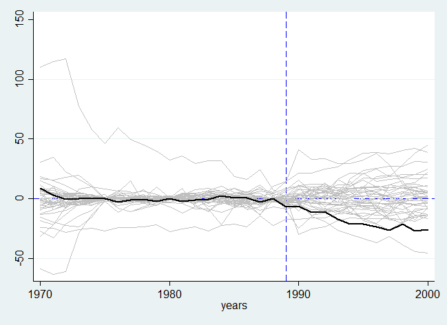

```stata
.    graph export 7.png, replace
(file 7.png written in PNG format)
```

**Picture 4. Placebo Test**

You might consider dropping some of the extreme outliers or adjusting the range of the y-axis.